# Analyzing UFO Sightings

Shealagh Brown & Sam Zimpfer

2025-05-01

## Introduction

The data we were working with came from a data set called “UFO sightings scrubbed” that was found on Kaggle.com from a user named Akhil Goyal. The data was last updated three months ago but only contains data from 1906 till 2014. The data could have some bias if UFO sightings from certain regions of the world were not recorded or included in this data set, additionally it is observational data collected by different people around the globe which can create large amounts of variation.  
This data is of interest because UFOs have been a topic of public interest for years. With increasing amounts of interest in space travel and extraterrestrials in more recent years, the fascinations with UFOs has only grown stronger. For this project we want to explore what influences sightings as this can be valuable knowledge for those trying to investigate UFOs.  
In order to work with our data we had to clean it. This included converting the datetime column into year, month, day, seconds, minutes, hours format. Then we created a new data set where we added columns for years, seconds, and months and kept the updated datetime, city, state, country, longitude, and latitude columns. We then had to convert both longitude and latitude into numeric values in order to work with them. Additionally we had to remove some columns with improper formatting and we dropped any columns with NA’s. The variables we used and code for this data cleaning follows:

**datetime**: the date and time of sighting in year, month, day, hours, minutes, seconds format.  
**city**: city where sighitng occurred  
**state**: state where sighting occurred  
**country**: country where sighting occurred  
**seconds**: duration of sightings in seconds  
**latitude**: latitude of sighting  
**longitude**: longitude of sighing  
**year**: year when sighing occurred  
**month**: month when sighting occurred

```r
ufo_raw <- read.csv("ufo_sightings_scrubbed.csv")

#convert date time to ymd_hms format
ufo_raw$datetime <- ymd_hms(ufo_raw$datetime)

#cleaning data
ufo_raw|>
  # keep duration in seconds form only
   mutate(seconds = duration..seconds.,
          # split datetime data into a year and a month column
          year = year(datetime),
          month = month.name[month(datetime)])|>
  # select relevant columns
  select(datetime, city, state, country, seconds,latitude,longitude, year, month)|>
    filter(seconds <= 40000) |>
    # filter out badly formatted entries that could cause NA's during the following conversion
    filter(grepl("^[-]?[0-9.]+$", latitude),
           grepl("^[-]?[0-9.]+$", seconds)) -> ufo


ufo$latitude <- as.numeric(ufo$latitude) #changing lat to numeric
ufo$seconds <- as.numeric(ufo$seconds) #changing seconds to numeric

# drop any remaining NA entries
ufo <- ufo |> drop_na(longitude, latitude, seconds)
```

## Data Analysis

The first question we had about UFO sightings is how the location around the world influenced the number that occurred. We began by creating histograms for longitude and latitude. From there we created a scatter plot to compare latitude and longitude to see if there was a relationship between the two of them.

[figure not shown]

[figure not shown]

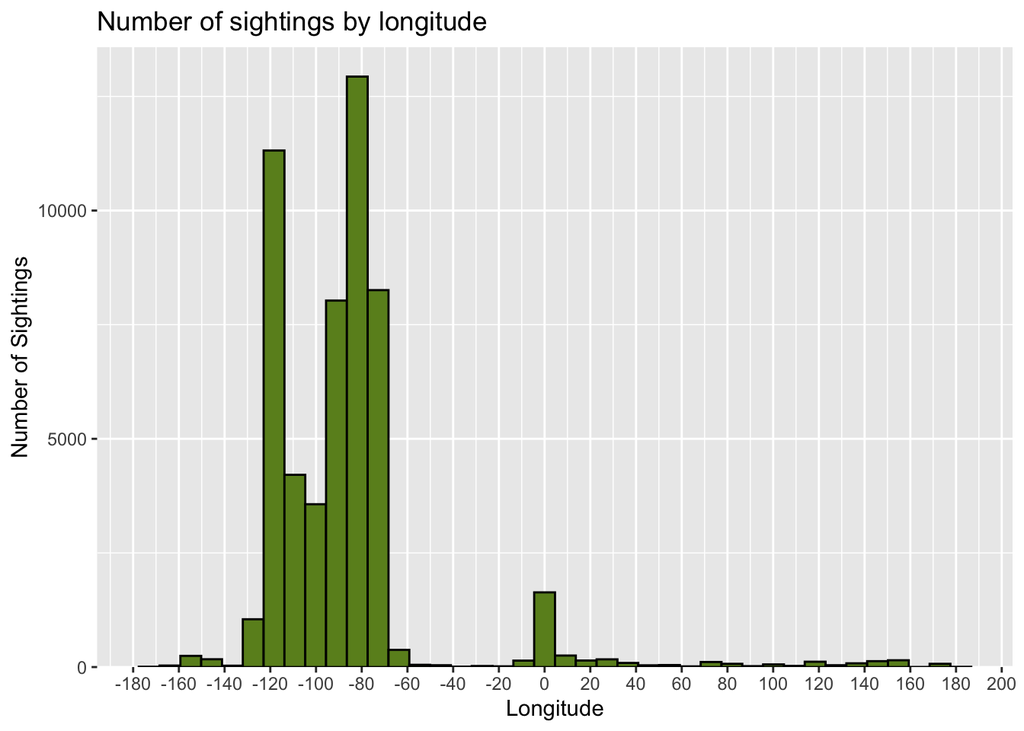

When looking at the histogram of longitude, we notice there are two main peaks within the spread. One peak is around -120 and the seconds is around -80. This make sense because these are the longitudes that correspond with highly populated areas of the US. The relative height of these peaks implies that there are considerably more sightings in the US than anywhere else in the world. This observation can be interpreted in multiple ways, either that UFO’s are more commonly reported in the US than anywhere else (either accurately or inaccurately), or that there really are more UFO visits in the US than anywhere else. We can’t make a solid determination between these two based on the data, but we can clearly see that there have been more reports around the US.

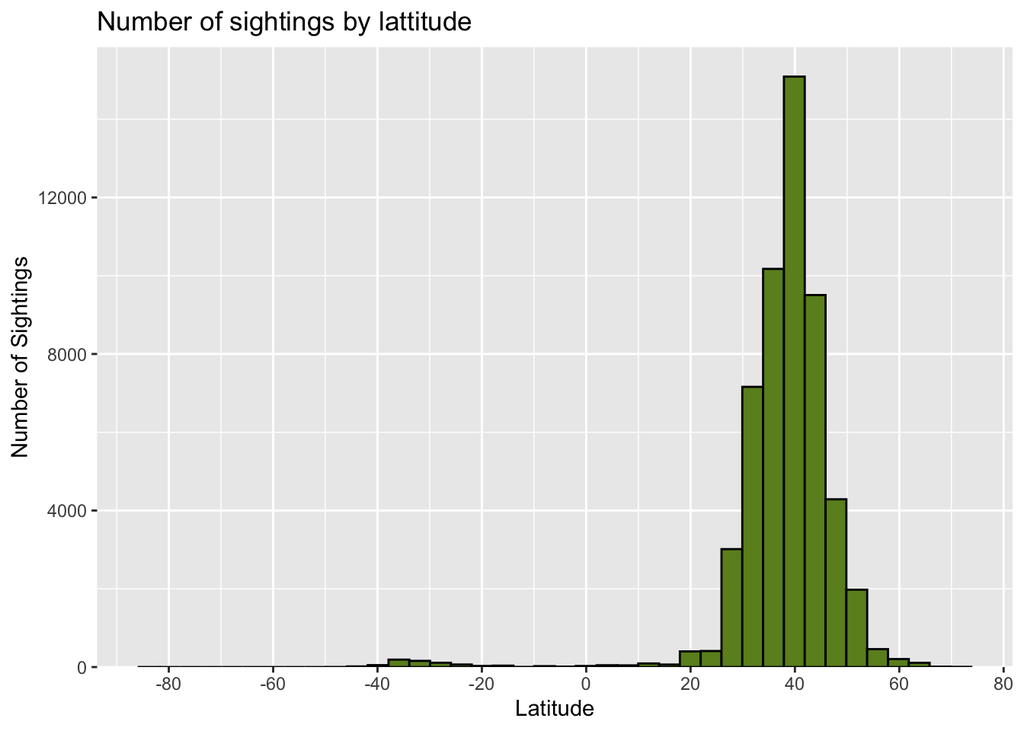

In the latitude histogram, we see than sightings are most prevalent around 40. Again, this corresponds to the coordinates of the US and also Europe, which is the second most frequently reported area of UFO sightings. This data supports the same conclusions we see from the longitude histogram.

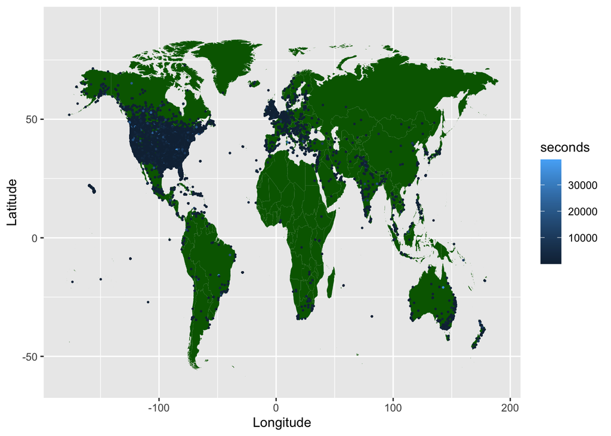

Here, we can see in greater detail the geographical dispersion of the sightings. The graph supports the same claims as the previous two graphs that there is a high volume of sightings in the United States. This graph also indicates other potential hot spots of sightings, specifically Europe and the eastern coast of Australia. The color coding makes it evident that most of the sightings are relatively short.

The next question we had was how the number of sightings had increase or decreased over the full epoch of time that the data set spans. We created a histogram of sightings per group of 5 years to answer this question.

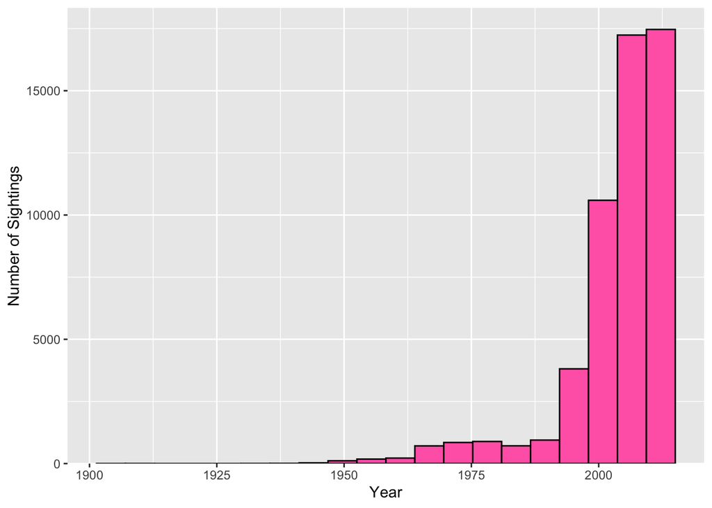

The histogram shows that UFO sightings were relatively infrequent in the early 1900’s. Sightings gradually started to increase during the 1950’s and then there was a sharp increase at the end of the 1990’s and into the 2000’s. The number of sightings seems to start to plateau past 2005 also, so it would interesting to see whether the data plateaus in the long term after this point or if it would continue to increase beyond a certain point. This pattern might indicate developments in human history that could be of interest to extraterrestrial beings or have sparked human interest in the existence of extraterrestrials.

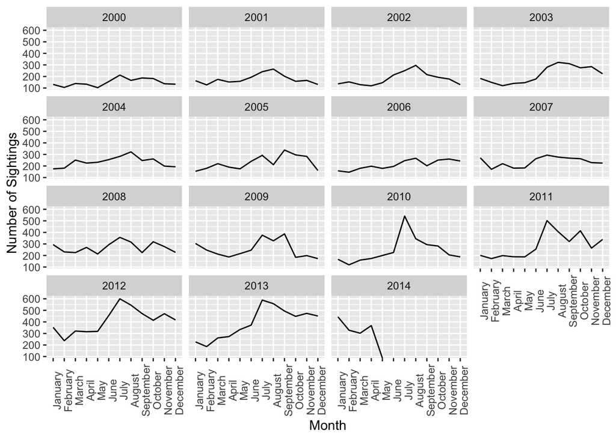

## Machine learning

### Linear Regression

We wanted to use machine learning techniques to predict the duration of sightings and the longitude/latitude they took place at. We first chose to try to create a linear regression model. We thought this would be appropriate as we wanted to explore how our explanatory variables could explain the duration of sightings which is a numerical response variable. We also thought this would be a good technique to use as it is an eager learner and we wanted to create a model.

```
## # A tibble: 3 × 4
##   explanatories          r.squared adj.r.squared   sigma
##   <chr>                      <dbl>         <dbl>   <dbl>
## 1 latitude             0.000000881    -0.0000177 142621.
## 2 longitude            0.0000784       0.0000598 142615.
## 3 latitude + longitude 0.0000999       0.0000627 142615.
```

#### Residual Plots for Duration of Sightings vs Longitude and Lattitude

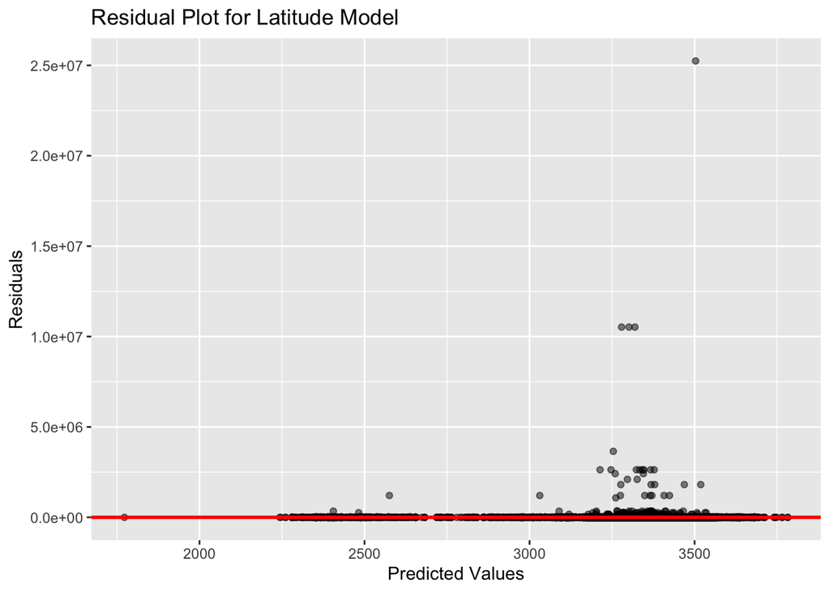

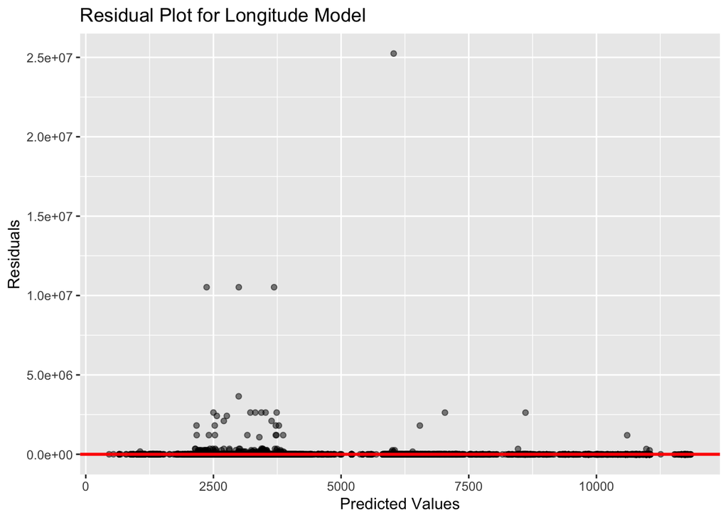

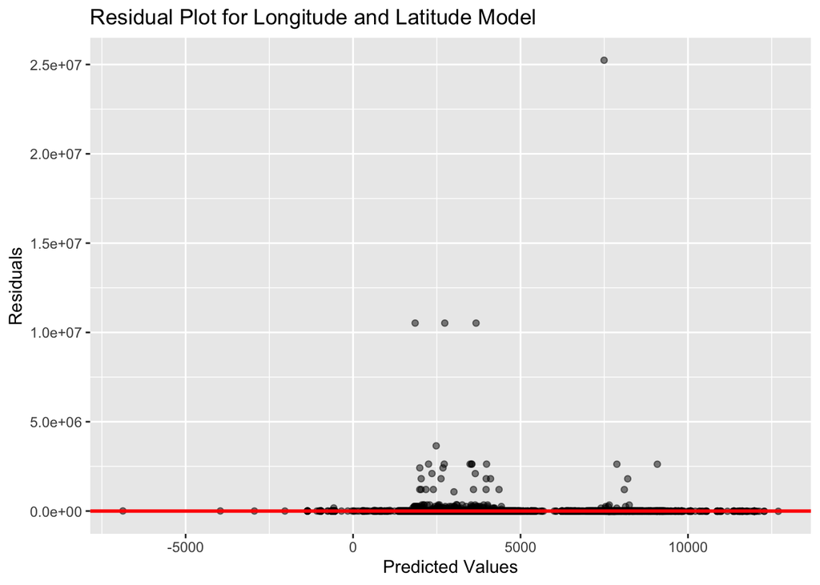

We created three different linear regression models, one with longitude as the explanatory variable, one with latitude as the explanatory variable, and the third with both. We wanted to compare which model would be the most accurate. From the table above we can see that all three models had R-squared values that were very close to zero. This indicates that our models were not a good predictor of duration of UFO sightings.

We then made residual graphs to see what else we could notice about our models and the data. These plots also indicate that the linear model is not a good predictor of duration based on longitude or latitude. In each plot there are clusters of outliers that are significantly higher than the majority of the data so the residuals dont have an even spread.

### kNN regression

Since our linear regression proved to not be effective in predicting duration of sightings based on longitude or latitude we decided to try a k Nearest Neighbors regression. We noticed that a large portion of the data was acting differently than the rest, and thought kNN regression could account for this.

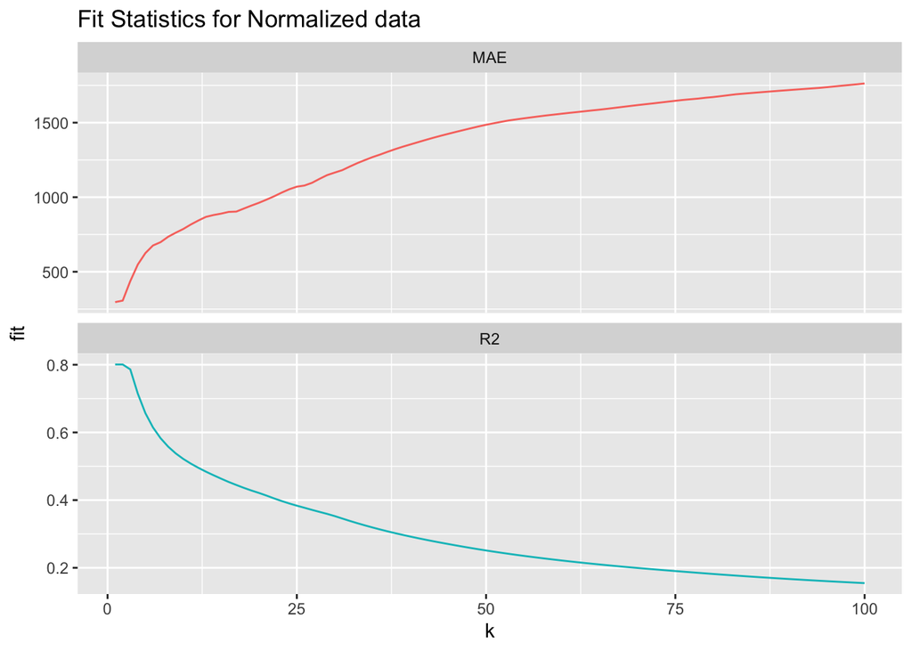

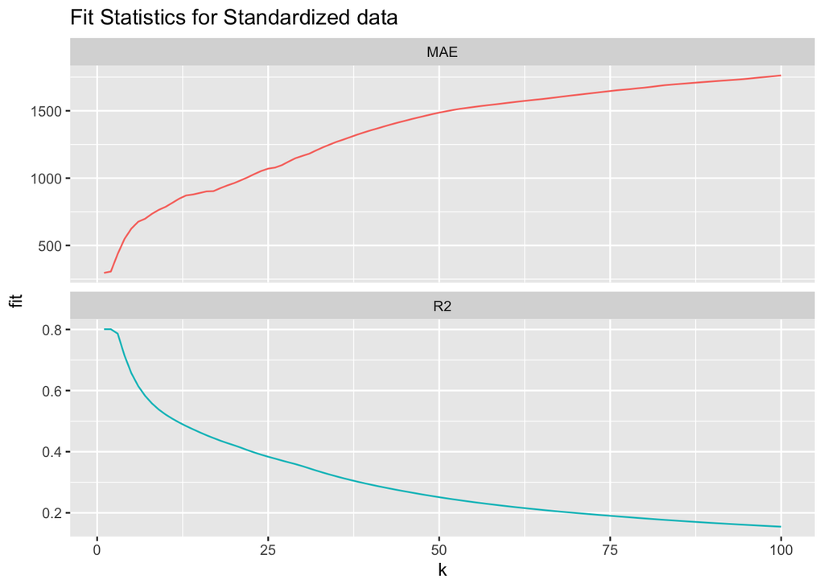

```
##   rescale k       R2     MAE
## 1    norm 1 0.800855 296.486
```

When looking at the fit statistic plots for both the normalized and standardized data we can see the R-squared values are at their max and the MAE is minimized at values close to one. We then searched the data to find the best k value, which ended up being a k value of one when using the normalized data. This k value is unusual and leads up to believe that this model is likely overfit to the data that we used to train it.

Both the linear regression and kNN regression failed to be good techniques for the effect of longitude and latitude on duration. This could be due to a lack of relationship between these variables. There is a large portion of the data where the sightings have a very short duration. There is also a second portion of the data that has much longer duration. Additionally, many sightings are concentrated in the United States and Europe. These nuances of the data could have influenced their behaviors with regression.

### kNN Classifications

We were also interested in using machine learning to see if we could use latitude and longitude to predict which month a sighting happened in. We started by using kNN classification because our response variable is categorical and we thought it would be an effective method of predicting month based on longitude and latitude.

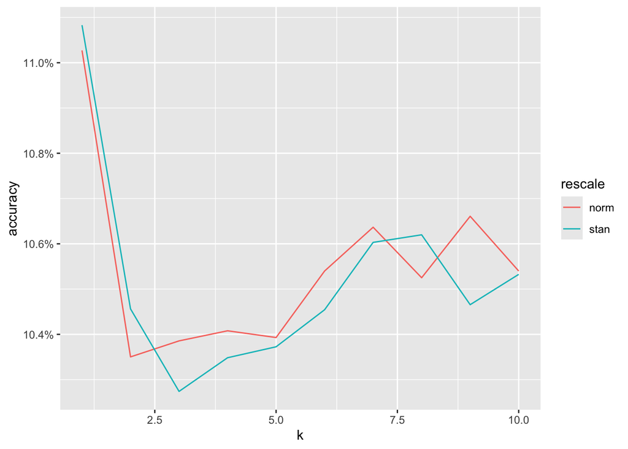

```
## # A tibble: 1 × 3
##       k rescale_method accuracy
##   <int> <chr>             <dbl>
## 1     1 stan_acc          0.111
```

```
## Confusion Matrix and Statistics
##
##            predicted
## actual      April August December February January July June March  May
##   April       213    463      193      175     232  591  425   203  196
##   August      289    788      286      232     315 1045  622   305  295
##   December    193    446      293      154     269  572  411   239  184
##   February    182    388      222      105     201  487  370   190  133
##   January     214    460      257      162     302  561  397   259  218
##   July        326    884      336      225     374 1273  678   317  328
##   June        293    687      309      210     313  893  692   319  269
##   March       199    433      255      157     252  546  427   227  194
##   May         200    447      216      122     226  625  375   194  182
##   November    260    514      288      163     277  703  487   291  205
##   October     277    569      278      206     243  780  531   271  231
##   September   272    699      268      177     299  866  587   270  267
##            predicted
## actual      November October September
##   April          303     315       356
##   August         466     545       595
##   December       335     365       346
##   February       285     275       310
##   January        286     346       348
##   July           477     588       634
##   June           432     489       538
##   March          335     343       329
##   May            273     321       346
##   November       437     453       407
##   October        403     611       477
##   September      370     469       540
##
## Overall Statistics
##
##                Accuracy : 0.1053
##                  95% CI : (0.1027, 0.108)
##     No Information Rate : 0.1663
##     P-Value [Acc > NIR] : 1
##
##                   Kappa : 0.0155
##
```

[output cut: 16 more lines]

```
## Pos Pred Value             0.079265     0.19767     0.12711     0.061401
## Neg Pred Value             0.939928     0.83796     0.89011     0.942920
## Prevalence                 0.061432     0.16631     0.11163     0.057377
## Detection Rate             0.005617     0.02368     0.01287     0.004222
## Detection Prevalence       0.070861     0.11978     0.10125     0.068760
## Balanced Accuracy          0.510959     0.51355     0.50790     0.502558
##                      Class: May Class: November Class: October Class: September
## Sensitivity            0.067358        0.099273        0.11934          0.10333
## Specificity            0.934495        0.917999        0.91231          0.90639
## Pos Pred Value         0.051602        0.097436        0.12528          0.10622
## Neg Pred Value         0.949841        0.919545        0.90777          0.90374
## Prevalence             0.050254        0.081872        0.09523          0.09720
## Detection Rate         0.003385        0.008128        0.01136          0.01004
## Detection Prevalence   0.065598        0.083415        0.09071          0.09456
## Balanced Accuracy      0.500926        0.508636        0.51582          0.50486
```

### Classification Tree

The accuracy of our kNN classification was relatively low so we decided to make a classification tree to make a model of longitude, latitude, and the month of a sighting. We thought this may work better as it is a very large data set and classification trees are able to run quicker. Additonally it would provide a visualization and steps to take when determining the month of a sighting.

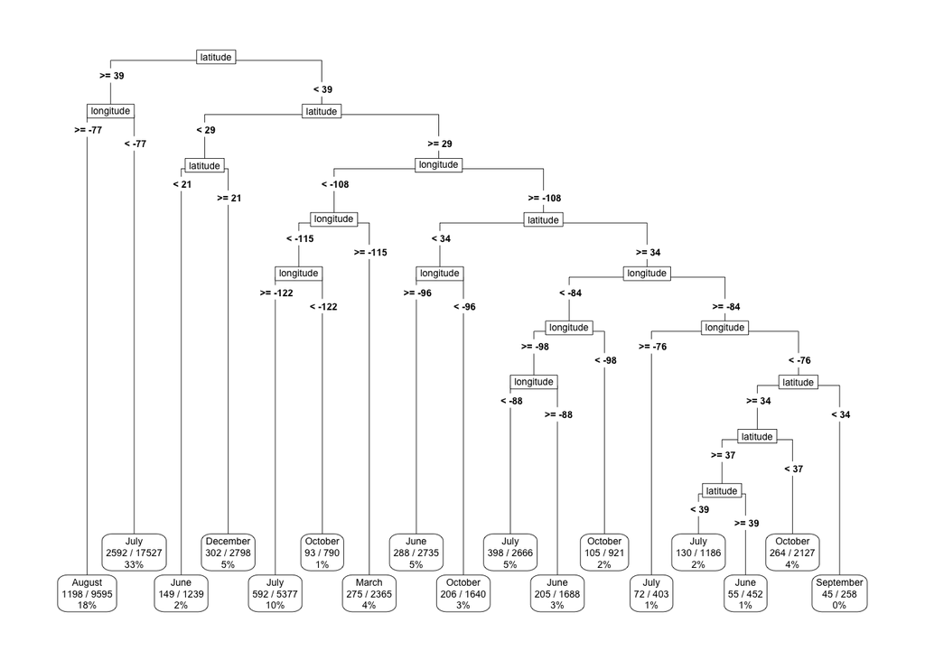

```
##            Overall
## latitude  668.5097
## longitude 397.5401
```